--- layout: default ---

## 🔍 Radar intraday: outliers nas negociações de 12/09 📊💡📈🚀

[figure not shown]

## **ALPK3**

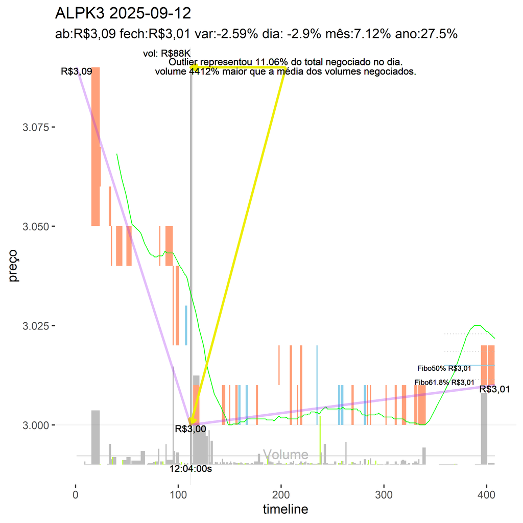

A seguir, desempenho do ativo ao longo do tempo:

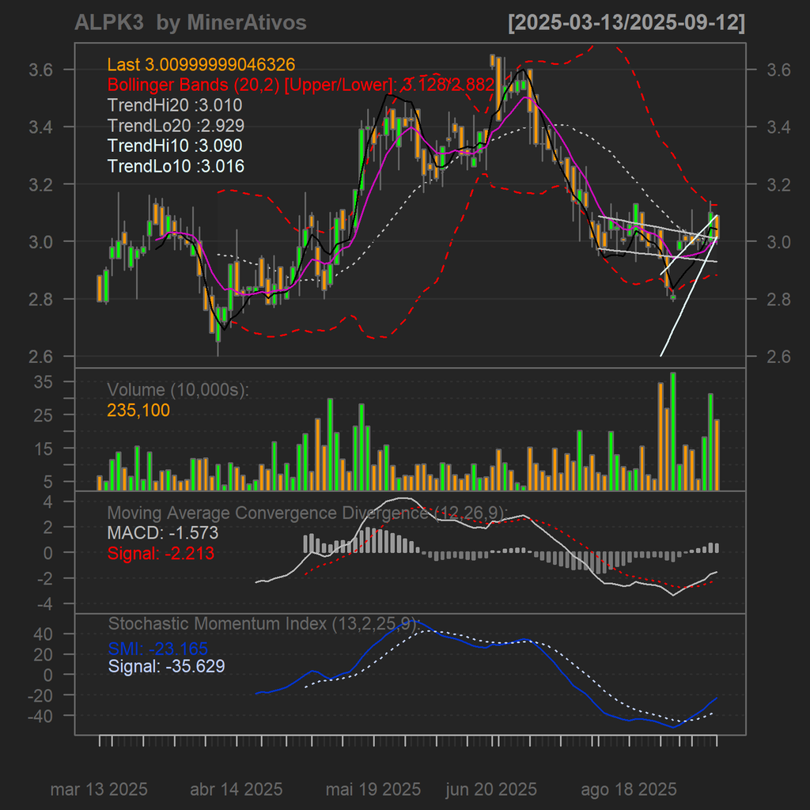

[figure not shown]

## **CSMG3**

A semana começou com um tom mais animado para a ação CSMG3, que protagonizou um desempenho impressionante na quinta-feira. Acompanhando a tendência de crescimento que vinha desde o início do mês, a cotação da ação alcançou um novo patamar, fechando a sexta-feira em R$ 32,82.A abertura no dia foi sólida, com uma apreciação de 0,16% em relação ao fechamento anterior, e isso se traduziu em uma variação acumulada de 2,79% desde o dia anterior. Este ganho é mais um capítulo na história de sucesso da ação, que já apresentou crescimentos expressivos nos últimos meses: uma variação mensal de 12,7%, trimestral de 17,3% e anual de 55,8%.Mas o que chamou atenção foi o destaque no intraday, quando às 16:14:00h, houve um ponto de negociação que representou 21,94% do total negociado no dia para a ação. Isso gerou uma variação de 1,33% na cotação logo após este momento crítico. É fácil entender por quais motivos a ação CSMG3 está se tornando cada vez mais popular entre os investidores.No entanto, é importante lembrar que o desempenho da ação não é apenas um fato isolado, mas sim parte de uma tendência maior que já vinha sendo observada. É fundamental manter o olhar atento e monitorar os desenvolvimentos futuros para entender melhor as razões por trás deste sucesso. Veja a seguir o gráfico do intraday com o destaque do outlier: as setas amarelas destacam o momento e o volume negociado no ponto de outlier. A linha violeta demonstra a tendência do preço antes e depois do destaque.

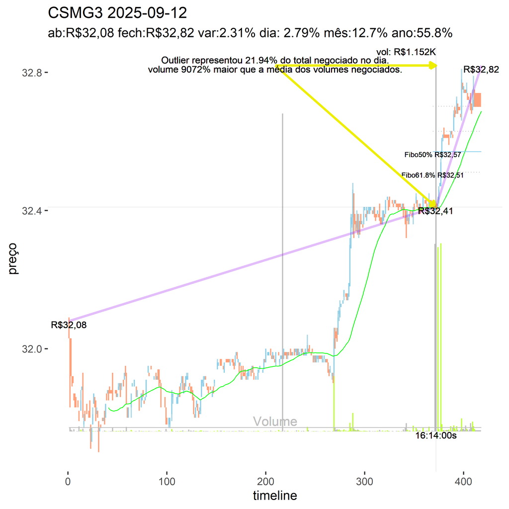

A seguir, desempenho do ativo ao longo do tempo:

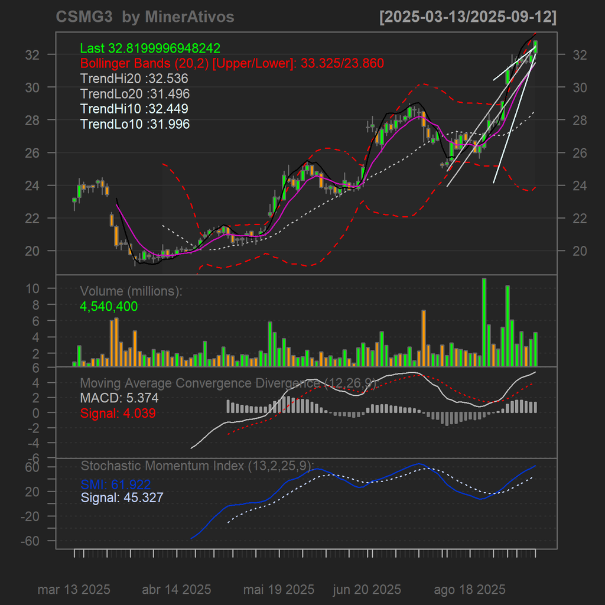

[figure not shown]

## **DASA3**

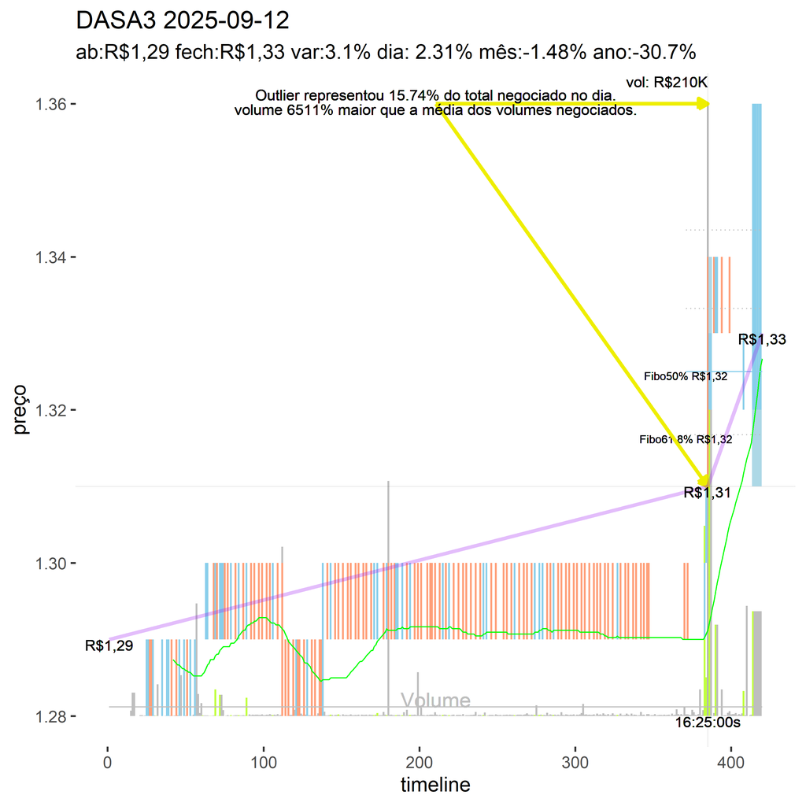

A seguir, desempenho do ativo ao longo do tempo:

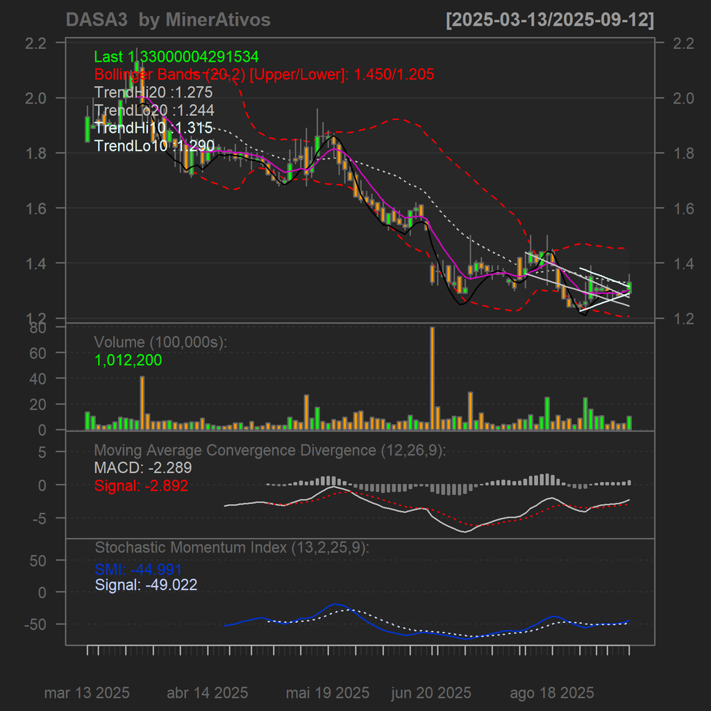

[figure not shown]

## **HBOR3**

Hoje, sexta-feira, 2025-09-12, a ação HBOR3 apresentou um desempenho intrigante no mercado de ações. A análise sugere que o ativo fechou o dia com uma cotação de R$ 3,55, após registrar um fechamento anterior de R$ 3,60.Apesar da leveza do mercado geral, a HBOR3 apresentou uma variação negativa de -1,39% em relação ao seu valor ao fechar no dia anterior. No entanto, o que chama a atenção é a mudança brusca na cotação do ativo logo após as 10:31:00s, quando houve um ponto de negociação anômalo que representou 10,37% do total negociado no dia.Essa outlier no intraday teve um impacto significativo na cotação da ação, que variou -2,708% logo após esse ponto. Embora a variação mensal seja de 8,9%, e a trimestral seja de 38,7%, o desempenho diário da HBOR3 é preocupante, especialmente considerando que a variação anual é de 154%.Aumento significativo no volume negociado com relação ao dia anterior (59,5%) também chamou a atenção. Juntos, esses dados sugerem uma certa volatilidade na cotação da HBOR3, tornando-a uma escolha mais arriscada para os investidores. Veja a seguir o gráfico do intraday com o destaque do outlier: as setas amarelas destacam o momento e o volume negociado no ponto de outlier. A linha violeta demonstra a tendência do preço antes e depois do destaque.

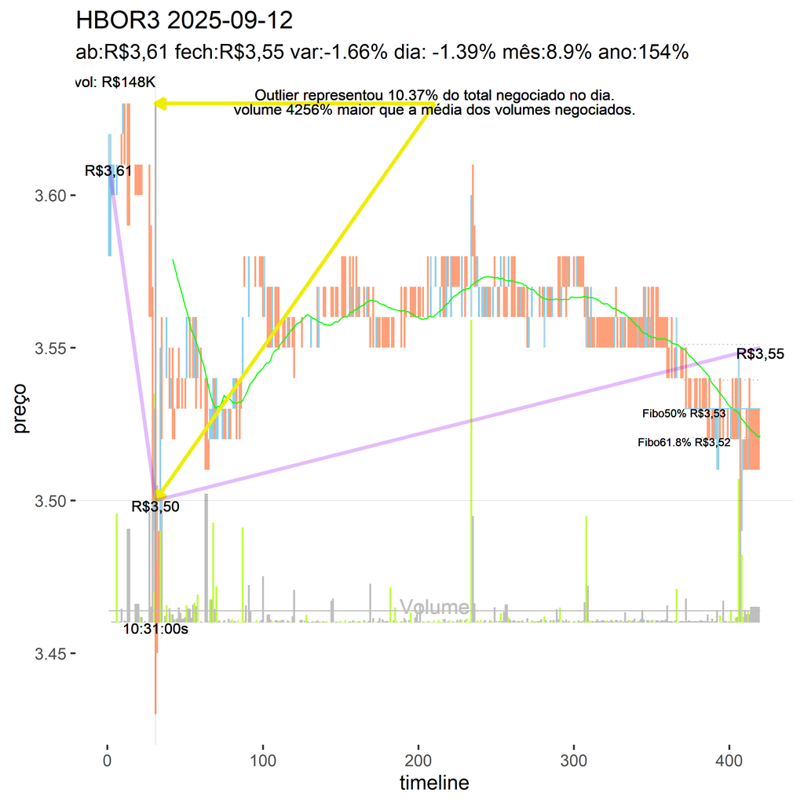

A seguir, desempenho do ativo ao longo do tempo:

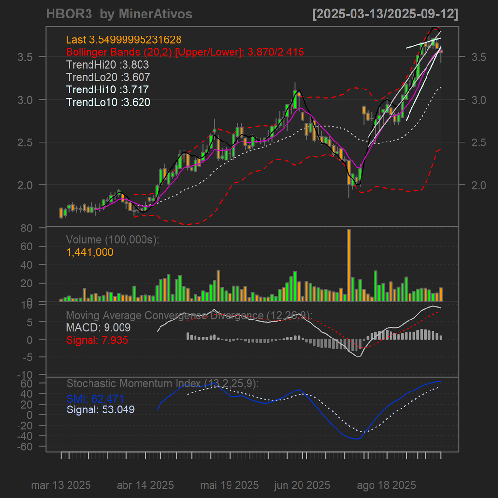

[figure not shown]